# Introduction to Databases and Data Modelling

Author

Oliver Gregory

Published

October 1, 2024

# Conceptual data modelling using the Entity-Relationship (E-R) model

**Queries**

- What is a cardinality ratio?

## Conceptual modelling

Conceptual modelling referes to the **conceptual database design**, usually expressed through a conceptual model (with high abstraction) or an Entity-Relationship (E-R) model.

E-R models are largely supported by database design tools. An E-R model comprises data structures (entities), their relationships, and constraints, and is represented through an E-R diagram.

**Tip**

It is important to note that the term database application usually refers to a particular database and the associated programs that implement the database queries and updates. Traditionally, the design and test of application programs have been considered part of software engineering rather than database design, but they can be intertwined as they are strongly related.

## Main phases of database design

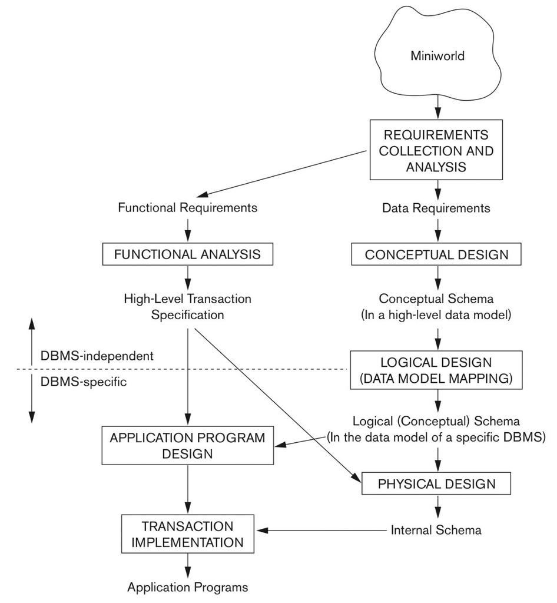

- **Requirements collection and analysis**: database designers interview users to understand and document their data requirements from a mini world scenario.
- **Functional analysis**: the functional requirements refer to user-defined operations (or transactions) that will be applied to the database, including retrievals and updates.
- **Conceptual design**: high-level conceptual schema describing data requirements, entity types, relationships and constraints. No implementation details.
- **Logical design**: implementation of the database using a commercial DBMS. Mapping from the conceptual schema to an implementation data model, such as the relational SQL model.
- **Physical design**: specification of internal structures, file organizations, indexes, access paths, and physical design parameters.
- **Application programs**: they are designed in parallel to the database design, based on high-level transaction specifications.

## Notation for conceptual diagrams

## Composite vs simple (atomic) attributes

## Single-valued vs multi-valued attributes

## Stored vs derived attributes

## Null values

## Complex attributes

## Entity types and entity sets

## Representation and key attributes of an entity type

## Value sets (domains) of attributes

## Relationship types and sets

## Relationships as attributes

## Role names and recursive relationships

## Cardinality ratios for binary relationships

## Participation constraints and existence dependencies

## Attributes of relationship types

## (min, max) notation for conceptual diagrams

## Higher degree (>2) relationships